Peer Assessment 1

# Load Packages

```r
library(ggplot2)
library(scales)
library(Hmisc)
```

# Loading and preprocessing the data.

```r
ActivityData <- read.csv("./Data/activity.csv")
head(ActivityData)
```

```
##   steps       date interval
## 1    NA 2012-10-01        0
## 2    NA 2012-10-01        5
## 3    NA 2012-10-01       10
## 4    NA 2012-10-01       15
## 5    NA 2012-10-01       20
## 6    NA 2012-10-01       25
```

# What is mean total number of steps taken per day?

```r
StepsByDay <- tapply(ActivityData$steps, ActivityData$date, sum, na.rm=TRUE)
```

## 1.Make a histogram of the total number of steps taken each day

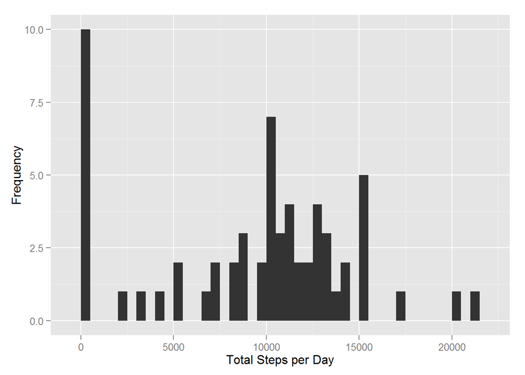

```r
qplot(StepsByDay, xlab='Total Steps per Day', ylab='Frequency', binwidth=500)
```

## 2. Calculate and report mean and median total number of steps taken by day.

```r
MeanStepsByDay <- mean(StepsByDay)
MedianStepsByDay <- median(StepsByDay)

MeanStepsByDay
```

```
## [1] 9354.23
```

```r
MedianStepsByDay
```

```
## [1] 10395
```

# What is the average daily activity pattern?

```r
AVGStepsPerTime <- aggregate(x=list(MeanSteps=ActivityData$steps), by=list(interval=ActivityData$interval), FUN=mean, na.rm= TRUE)
```

## 1. Make a time series plot of the 5-minute interval

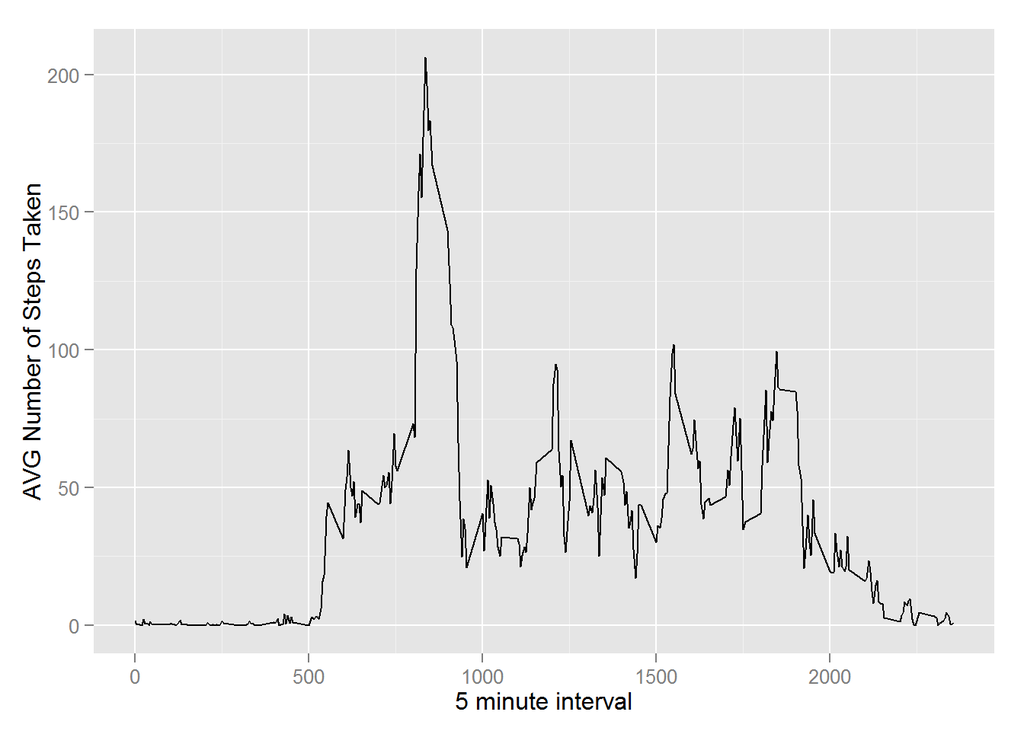

```r
ggplot(data=AVGStepsPerTime, aes(x=interval, y=MeanSteps)) +
  geom_line() +
  xlab('5 minute interval')+
  ylab('AVG Number of Steps Taken')
```

## 2. Which interval contains the maximum number of steps, AVG.

```r
MaxSteps <- which.max(AVGStepsPerTime$MeanSteps)

MaxStepsTime <- gsub("([0-9]{1,2})([0-9]{2})", "\\1:\\2", AVGStepsPerTime[MaxSteps, 'interval'])
MaxStepsTime
```

```
## [1] "8:35"
```

# Imputing missing values

## 1. Calculate and report the total number of missing values in the dataset.

```r
MissingValues <- length(which(is.na(ActivityData$steps)))
MissingValues
```

```
## [1] 2304
```

## 2. Devise a strategy for filling in all of the missing values in the dataset.

## 3. Create a new dataset that is equal ti the original dataset but with the missing data filled in.

```r
ActivityDataImputed <- ActivityData

ActivityDataImputed$steps <- impute(ActivityData$steps, fun=mean)
```

## 4. Make a histogram of the total number of steps taken each day.

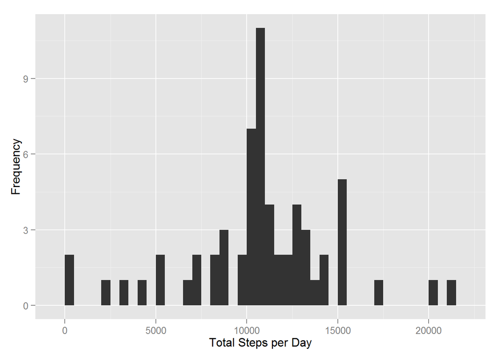

```r
StepsByDayImputed <- tapply(ActivityDataImputed$steps, ActivityDataImputed$date, sum)

qplot(StepsByDayImputed, xlab='Total Steps per Day', ylab='Frequency', binwidth=500)
```

## Calculate and report the mean and median total number of steps taken per day.

```r
MeanStepsByDayImuted <- mean(StepsByDayImputed)
MedianStepsByDayImputed <- median(StepsByDayImputed)

MeanStepsByDayImuted
```

```
## [1] 10766.19
```

```r
MedianStepsByDayImputed
```

```
## [1] 10766.19
```

# Are there differences in activity patterns between weekdays and weekends?

## 1. Create a new factor variable in the dataset with two levels ??? “weekday” and “weekend” indicating whether a given date is a weekday or weekend day.

```r
ActivityDataImputed$DateType <- ifelse(as.POSIXlt(ActivityDataImputed$date)$wday %in% c(0,6), 'weekend', 'weekday')
```

## 2. Make a panel plot containing a time series plot of the 5-minute interval (x-axis) and the average number of steps taken, averaged across all weekday days or weekend days (y-axis).

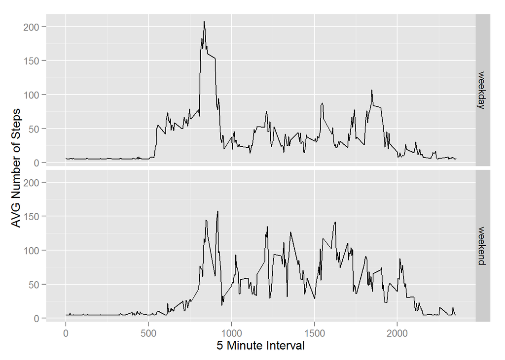

```r
AVGStepsPerTimeImputed <- aggregate(steps ~ interval + DateType, data = ActivityDataImputed, mean)

ggplot(AVGStepsPerTimeImputed, aes(interval, steps)) +
  geom_line() +
  facet_grid(DateType ~ .) +
  xlab("5 Minute Interval") +
  ylab("AVG Number of Steps")
```